# Robo Advisors

Yao-Jen Kuo

February 18, 2016

# Fields of Quantitative Finance

Before we dive into **Robo Advisors**, it is always good to take a quick glance at the fields of quantitative finance.

Quantitative finance is a field of applied mathematics, concerned with financial markets. Generally, mathematical finance will derive and extend the mathematical or numerical models without necessarily establishing a link to financial theory.

The application fields could be summarized as:

- Asset Pricing Models
- Portfolio Optimization
- Fixed Income Securities
- Derivatives Pricing
- Asset and Liability Management
- Capital Adequacy
- Credit Risk Management
- Extreme Value Theory

# Application fields of Robo Advisors

**Robo Advisors** are online wealth management platforms that use technology to provide automated, algorithm-based portfolio management advice, limiting the need of human intervention for individuals.

# Look closer on Robo Advisors

- At the center of all robo advisors are algorithms such as **Modern Portfolio Theory**
- An investor typically answers a series of questions about their finances, goals and risk tolerance before using the service
- Fees for most robo-advisors range from free to 0.5% of assets, costs are 50-75% lower than their human counterparts
- Typically offer only **index funds** and **ETFs**
- Most don’t allow investments in individual stocks
- Adopt a “passive” management style and aim to match the performance of a market index
- Do not get involved in the more personal aspects of wealth management, such as taxes, insurance, retirement, estate planning or cash-flow management

# So-called Modern Portfolio

- Algorithm-based automated investment solutions to conduct portfolio management since at least 2005
- So let’s look back to the application field of quantitative finance: **Portfolio Optimization**

# Quick demo on Portfolio Optimization

IT stock prices from package **Quandl**.

```r
packs <- c("Quandl", "timeSeries", "PerformanceAnalytics", "fPortfolio")
sapply(packs, library, character.only = TRUE)
```

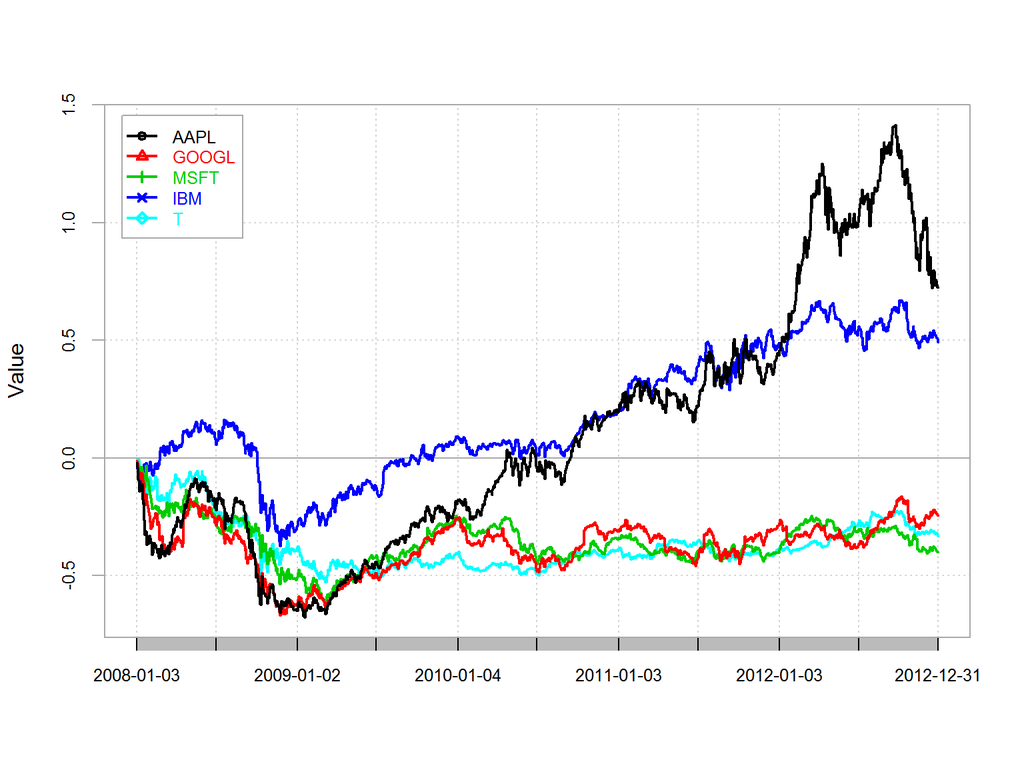

```r
Quandl.api_key("RAx2-XZH5-vUd5qvHS1k")
AAPL <- Quandl('WIKI/AAPL',start_date = '2008-01-01', end_date = '2012-12-31')
GOOGL <- Quandl('WIKI/GOOGL',start_date = '2008-01-01', end_date = '2012-12-31')
MSFT <- Quandl('WIKI/MSFT',start_date = '2008-01-01', end_date = '2012-12-31')
IBM <- Quandl('WIKI/IBM',start_date = '2008-01-01', end_date = '2012-12-31')
T <- Quandl('WIKI/T',start_date = '2008-01-01', end_date = '2012-12-31')
IT <- cbind(AAPL[,1:2], GOOGL[,2], MSFT[,2], IBM[,2], T[, 2])
names(IT)[2:6] <- c('AAPL', 'GOOGL', 'MSFT', 'IBM', 'T')
IT <- timeSeries(IT[, 2:6], IT[, 1])
IT_return <- returns(IT)
chart.CumReturns(IT_return, legend.loc = 'topleft', main = '')
```

# The result of optimization

```r
Spec <- portfolioSpec()
setSolver(Spec) <- "solveRshortExact"
Frontier <- portfolioFrontier(as.timeSeries(IT_return), Spec, constraints = "Short")
Frontier
```

```
##
## Title:
##  MV Portfolio Frontier
##  Estimator:         covEstimator
##  Solver:            solveRshortExact
##  Optimize:          minRisk
##  Constraints:       Short
##  Portfolio Points:  5 of 50
##
## Portfolio Weights:
##       AAPL   GOOGL    MSFT     IBM       T
## 1  -0.2464  0.1557  0.3258  0.2605  0.5045
## 13 -0.1291  0.0989  0.1826  0.4785  0.3692
## 25 -0.0118  0.0421  0.0393  0.6965  0.2339
## 37  0.1056 -0.0148 -0.1040  0.9145  0.0987
## 50  0.2327 -0.0763 -0.2592  1.1507 -0.0479
##
## Covariance Risk Budgets:
##       AAPL   GOOGL    MSFT     IBM       T
## 1  -0.1656  0.1430  0.3258  0.2019  0.4949
## 13 -0.1222  0.0988  0.1857  0.4636  0.3741
## 25 -0.0130  0.0399  0.0352  0.7257  0.2123
## 37  0.1174 -0.0117 -0.0717  0.8956  0.0705
## 50  0.2327 -0.0460 -0.1224  0.9598 -0.0241
##
## Target Returns and Risks:
##       mean     Cov    CVaR     VaR
## 1  -0.0002  0.0149  0.0345  0.0223
## 13  0.0000  0.0141  0.0337  0.0215
## 25  0.0002  0.0144  0.0351  0.0223
## 37  0.0005  0.0156  0.0379  0.0249
## 50  0.0007  0.0177  0.0422  0.0272
##
## Description:
##  Thu Feb 18 10:02:57 2016 by user: twntok
```

# And the efficiency frontier

It is easy to render the **efficiency frontier**.

[figure not shown]

```r
frontierPlot(Frontier, col = rep('orange', 2), pch = 19)
monteCarloPoints(Frontier, mcSteps = 1000, cex = 0.25, pch = 19)
grid()
```

# Reference

- [Robo Advisors Are Expanding Rapidly and Challenging Swiss Market](http://fintechnews.ch/536/roboadvisor_onlinewealth/robo-advisors-are-expanding-rapidly-and-challenging-swiss-market/)
- [The Rise of Robo Advisors](https://www.marketstrategies.com/blog/2015/06/the-rise-of-robo-advisors/)
- Introduction to R for Quantitative Finance